# Neural Network and Deep Learning (Practice)

Biostat 203B

Author

Dr. Hua Zhou @ UCLA

Published

March 3, 2026

## 1 Learning sources

This lecture draws heavily on following sources.

- [*Deep Learning with Python*](https://www.manning.com/books/deep-learning-with-python) by Francois Chollet.
- [*Deep Learning Tuning Playbook*](https://github.com/google-research/tuning_playbook) by Google Research.
- *Learning Deep Learning* lectures by Dr. Qiyang Hu (UCLA Office of Advanced Research Computing): https://github.com/huqy/deep_learning_workshops

## 2 Software

- High-level software focuses on user-friendly interface to specify and train models.  
  [Keras](https://keras.io), [PyTorch](http://pytorch.org), [scikit-learn](http://scikit-learn.org/stable/), …
- Lower-level software focuses on developer tools for implementing deep learning models.  
  [TensorFlow](https://www.tensorflow.org), [PyTorch](http://pytorch.org), CNTK, Theano (stopped development!), [Caffe](http://caffe.berkeleyvision.org), [Torch](http://torch.ch), …
- Most tools are developed in Python plus a low-level language (C/C++, CUDA).

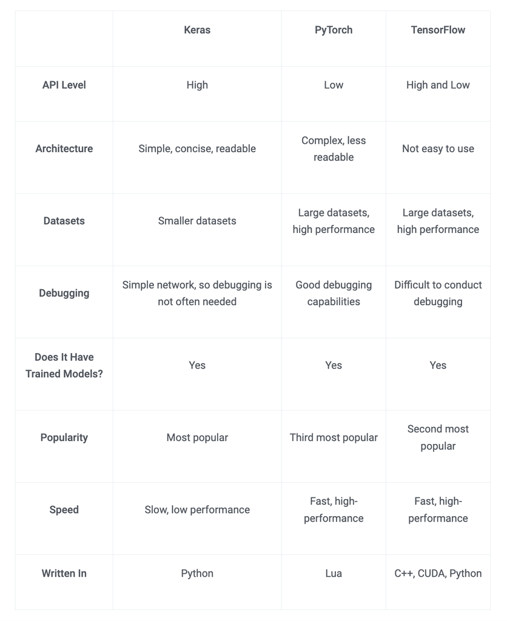

Source: https://www.simplilearn.com/keras-vs-tensorflow-vs-pytorch-article

## 3 TensorFlow

- Developed by Google Brain team for internal Google use. Formerly DistBelief.
- Open sourced in Nov 2015.
- OS: Linux, MacOS, and Windows (since Nov 2016).
- GPU support: NVIDIA CUDA.
- TPU (tensor processing unit), built specifically for machine learning and tailored for TensorFlow.
- Mobile device deployment: TensorFlow Lite (May 2017) for Android and iOS.

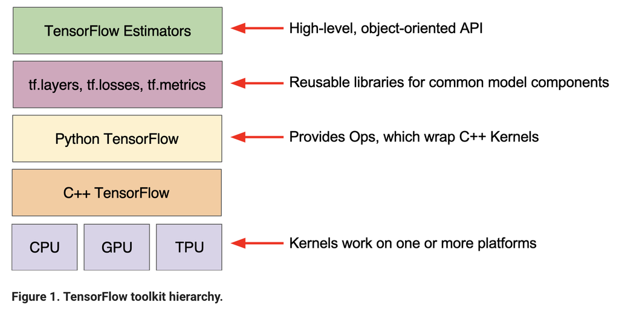

- TensorFlow supports [distributed training](https://www.tensorflow.org/guide/distributed_training).
- TensorFlow does not support Apple Silicon (M1/M2/M3) directly, but Apple provides the [`tensorflow-macos`](https://developer.apple.com/metal/tensorflow-plugin/) package for running on M1/M2 GPUs.
- Used in variety of Google apps: speech recognition (Google assistant), Gmail (Smart Reply), search, translate, self-driving car, …

> when you have a hammer, everything looks like a nail.

[figure not shown]

## 4 Workflow for a deep learning network

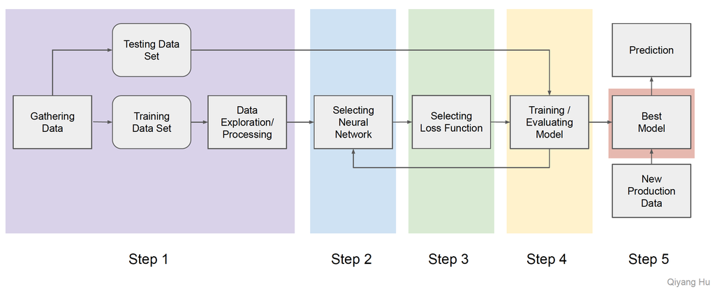

### 4.1 Step 1: Data ingestion, preparation, and processing

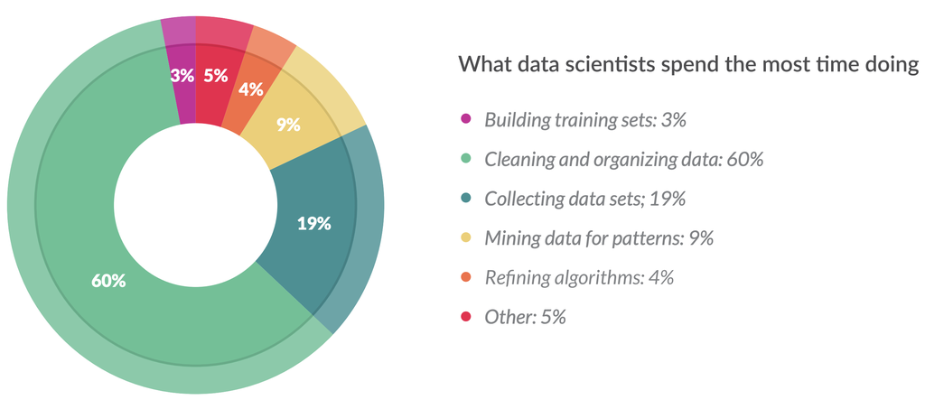

Source: [CrowdFlower](https://visit.figure-eight.com/rs/416-ZBE-142/images/CrowdFlower_DataScienceReport_2016.pdf)

- The most time-consuming but the most *creative* job. Take >80% time, require experience and domain knowledge.
- Determines the upper limit for the goodness of DL. `Garbage in, garbage out`.
- For structured/tabular data.

[figure not shown]

- Data prep for special DL tasks.
  - Image data: pixel scaling, train-time augmentation, test-time augmentation, convolution and flattening.
  - Data tokenization: break sequences into units, map units to vectors, align and pad sequences.
  - Data embedding: sparse to dense, merge diverse data, preserve relationship, dimension reduction, Word2Vec, be part of model training.

### 4.2 Step 2: Select neural network

- Architecture.

[figure not shown]

Source: https://www.asimovinstitute.org/neural-network-zoo/

- Activation function.

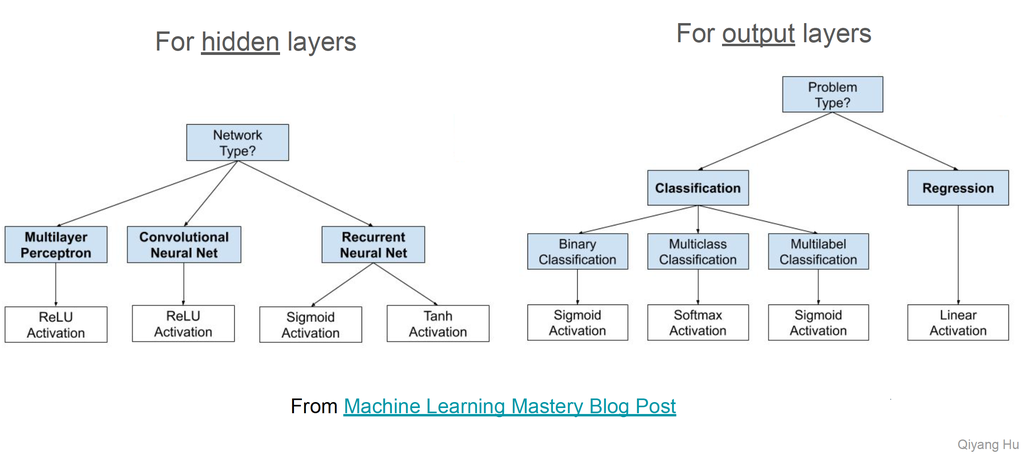

### 4.3 Step 3: Select loss function

- Regression loss: MSE/quadratic loss/L2 loss, mean absolute error/L1 loss.
- Classification loss: cross-entropy loss, …
- Customized losses.

### 4.4 Step 4: Train and evaluate model

- Choose optimization algorithm. Generalization (SGD) vs convergence rate (adaptive).
  - Stochastic GD.
  - Adding momentum: classical momentum, Nesterov acceleration. [Visualize](https://ucla-biostat-216.github.io/2022fall/slides/13-optim/13-optim.html)
  - Adaptive learning rate: AdaGrad, AdaDelta, RMSprop.
  - Comining acceleration and adaptive learning rate: ADAM (default in many libraries).
  - Beyond ADAM: [lookahead](https://arxiv.org/abs/1907.08610), [RAdam](https://arxiv.org/abs/1908.03265), [AdaBound/AmsBound](https://syncedreview.com/2019/03/07/iclr-2019-fast-as-adam-good-as-sgd-new-optimizer-has-both/), [Range](https://arxiv.org/abs/1908.00700v2), [AdaBelief](https://arxiv.org/abs/2010.07468).

*A Visual Explanation of Gradient Descent Methods (Momentum, AdaGrad, RMSProp, Adam)* by Lili Jiang: https://towardsdatascience.com/a-visual-explanation-of-gradient-descent-methods-momentum-adagrad-rmsprop-adam-f898b102325c

- Fitness of model: underfitting vs overfitting.

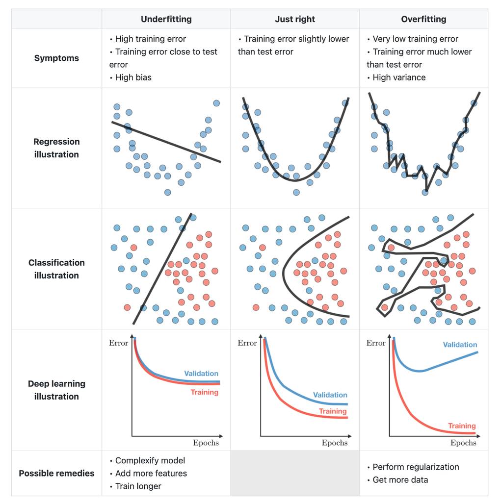

Source: https://stanford.edu/~shervine/teaching/cs-229/cheatsheet-machine-learning-tips-and-tricks

- Model selection: $K$-fold cross validation.

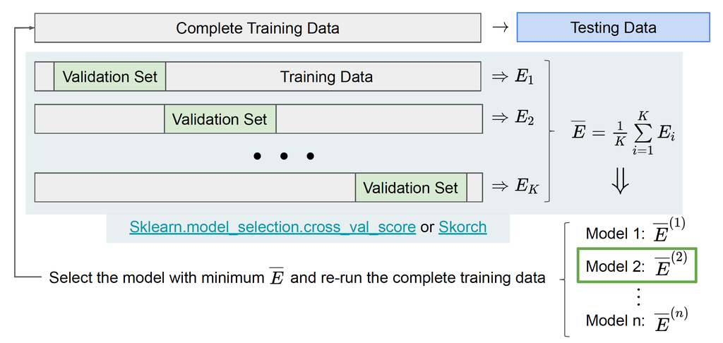

## 5 Keras examples

Following are selected examples from the collection of [Keras code examples](https://keras.io/examples/).

## 6 Example: MNIST - MLP

qmd, html.

## 7 Example: CIFAR100 - CNN

qmd, html.

## 8 Example: Using Pretrained Resnet50 to classify natural images

qmd, html.

## 9 Example: IMDB review sentiment analysis - Lasso, MLP, RNN, LSTM, transformer

- [Lasso penalized logistic regression](https://ucla-biostat-203b.github.io/2025winter/slides/15-nn/imdb/imdb_lasso.html)
- [MLP](https://ucla-biostat-203b.github.io/2025winter/slides/15-nn/imdb/imdb_mlp.html)
- [RNN](https://ucla-biostat-203b.github.io/2025winter/slides/15-nn/imdb/imdb_rnn.html)
- [LSTM](https://ucla-biostat-203b.github.io/2025winter/slides/15-nn/imdb/imdb_lstm.html)
- [Transformer](https://ucla-biostat-203b.github.io/2025winter/slides/15-nn/imdb/imdb_transformer.html)
- [Warm-start using pre-trained embedding in TF Hub](https://ucla-biostat-203b.github.io/2025winter/slides/15-nn/imdb/imdb_tfhub.html)

## 10 Example: Generate Artificial Faces with GAN

- [Generate Artificial Faces with CelebA Progressive GAN Model](https://ucla-biostat-203b.github.io/2025winter/slides/15-nn/progan/progan.html)

## 11 Example: Neural style transfer

- [Neural style transfer](https://ucla-biostat-203b.github.io/2025winter/slides/15-nn/style_transfer/style_transfer.html)